# Antigua AGRRA 2025

# Fish

Data overview:

Notes + questions:

- To include commercially significant species, would have to go back to raw 2025 data or do custom calculations by family

## Biomass

Data overview:

- 2017: FishBiomassByTransect.xlsx
  - “Data” sheet has transect-level data by family and group
- 2025: FishBiomassByTransect.xlsx
  - “Overall” sheet has transect-level data by family
  - Family sheets have transect-level data by species

### Import + wrangle data

```r
fish_bm_2017 <- read_excel(here("agrra_monitoring", "data_raw", "ATG_NEMMA_2017", "FishBiomass", "FishBiomassByTransect.xlsx"), sheet = "Data") %>%
  clean_names() %>%
  select(site, transect = trans, total = t, scar = parr, acan = surg) %>%
  mutate(year = "2017")

fish_bm_2025 <- read_excel(here("agrra_monitoring", "data_raw", "ATG_NEMMA_2025", "Calculated", "FishBiomassByTransect.xlsx"), sheet = "Overall") %>%
  clean_names() %>%
  select(site = survey_name, transect = transect_name, total = all, scar = t_scar, acan = t_acan) %>%
  mutate(year = "2025",
         site = if_else(site == "Little Bird Patch", "Little Bird Backreef", site)) # inconsistency in site name between 2017 and 2025

fish_bm_trans <- bind_rows(fish_bm_2017, fish_bm_2025) %>%
  filter(site != "Cades Reef Outside East") # currently excluding as we have no historical data

fish_bm_site <- fish_bm_trans %>%
  group_by(site, year) %>%
  summarise(across(c(total, scar, acan),
                   list(mean = ~ mean(.x, na.rm = TRUE),
                        se   = ~ se(.x)),
                   .names = "{.col}_{.fn}"))
```

### Line plots

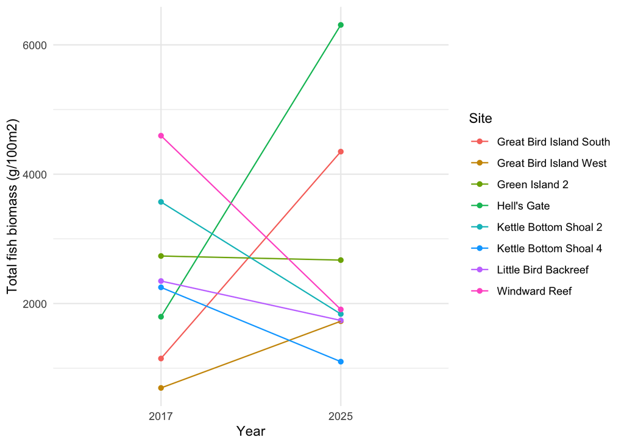

```r
ggplot(fish_bm_site, aes(x = year, y = total_mean, group = site, color = site)) +
  geom_point() +
  geom_line() +
  labs(x = "Year", y = "Total fish biomass (g/100m2)", color = "Site", group = "Site") +
  theme_minimal()
```

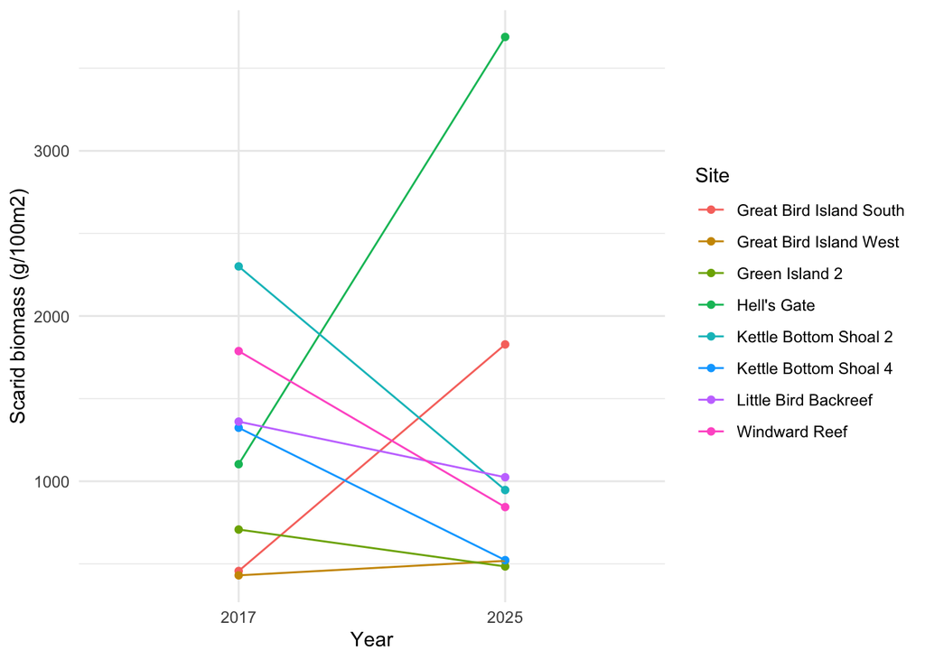

```r
ggplot(fish_bm_site, aes(x = year, y = scar_mean, group = site, color = site)) +
  geom_point() +
  geom_line() +
  labs(x = "Year", y = "Scarid biomass (g/100m2)", color = "Site", group = "Site") +
  theme_minimal()
```

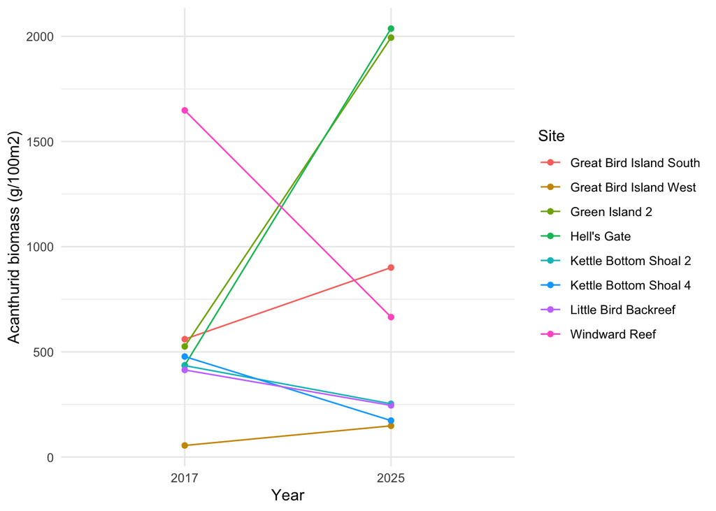

```r
ggplot(fish_bm_site, aes(x = year, y = acan_mean, group = site, color = site)) +
  geom_point() +
  geom_line() +
  labs(x = "Year", y = "Acanthurid biomass (g/100m2)", color = "Site", group = "Site") +
  theme_minimal()
```

## Length

Data overview:

- 2017: FishSizeByTransect.xlsx (binned data only)
  - NF (number of fish) + raw numbers and % in each size bin
  - % is out of 100
  - Everything above 40cm gets aggregated
  - One sheet per family has transect-level size data
- 2025: FishSizeFreqByTransect.xlsx (binned data only)
  - NF (number of fish) + % in each size bin
  - % is out of one (proportion)
  - Over 40cm, bins are by 10cm to the nearest 10cm until <200cm
  - “Overall” sheet has transect-level size data
  - Family sheets have data by family

Notes + questions:

- Dealing with >40cm fish given aggregation into one group in 2017? Need to check raw data
- Correct to keep transects with no fish and include in mean size calculations?
- Does “SEAB” in 2017 refer to serranids?
- Weighted means: calculate midpoint representation of each size bin and weight by the number of counts per bin

### Import + wrangle data

```r
# starting with scarids only as mock-up
fish_length_2017 <- read_excel(here("agrra_monitoring", "data_raw", "ATG_NEMMA_2017", "FishSize", "FishSizeByTransect.xlsx"), sheet = "PARR") %>%
  clean_names() %>%
  select(site, transect = trans, nf, contains("percent_")) %>%
  mutate(across(
    .cols = contains("percent_"),
    .fns  = ~ .x / 100)) %>%
  rename_with(~ str_remove_all(.x, "percent_")) %>%
  rename("40_up" = "40") %>%
  mutate(year = "2017")

fish_length_2025 <- read_excel(here("agrra_monitoring", "data_raw", "ATG_NEMMA_2025", "Calculated", "FishSizeFreqByTransect.xlsx"), sheet = "tSCAR") %>%
  clean_names() %>%
  select(site = survey_name, transect = transect_name, nf, starts_with("x")) %>%
  rename_with(~ str_remove_all(.x, "^(x)|(cm$)")) %>%
  rowwise() %>%
  mutate("40_up" = sum(c_across(matches("^\\d+$")), na.rm = TRUE)) %>% # select only columns with digits (e.g., 50, 60) and sum across these to be consistent with 2017 data, should not affect most of our fish families of interest
  ungroup() %>%
  select(!matches("^\\d+$")) %>%
  mutate(year = "2025",
         site = if_else(site == "Little Bird Patch", "Little Bird Backreef", site)) # inconsistency in site name between 2017 and 2025

fish_length_trans <- bind_rows(fish_length_2017, fish_length_2025) %>%
  filter(site != "Cades Reef Outside East") %>%
  select(-"40_up") # can't do anything with this atm because of 2017 aggregation - would need to check raw data

# check that all transects are present even if no fish per family were recorded
chk <- full_join(fish_length_trans %>%
                   group_by(year, site) %>%
                   summarize(count = n()),
                 fish_bm_trans %>%
                   group_by(year, site) %>%
                   summarize(count = n()),
                 by = c("year", "site"), suffix = c("_length", "_bm")) %>%
  filter(count_length != count_bm | is.na(count_length) | is.na(count_bm))
```

### Density plots

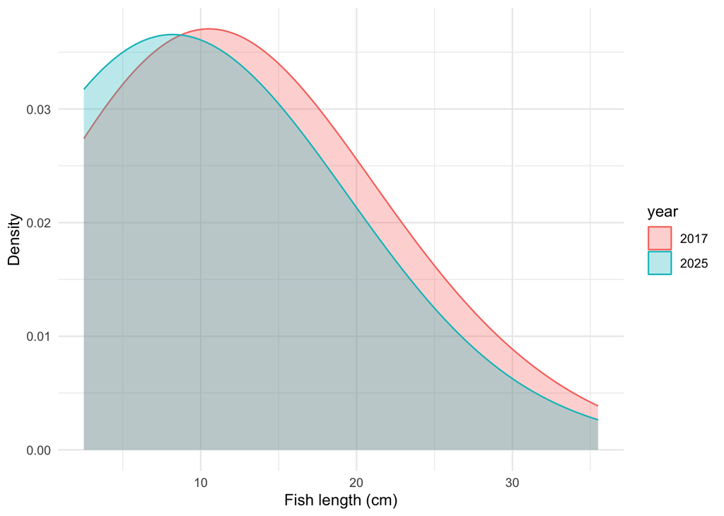

```r
# transform data for use in density plots
fish_long <- fish_length_trans %>%
  pivot_longer(
    cols = matches("^\\d+_?\\d?"),
    names_to = "length_mid",
    values_to = "percent"
  ) %>%
  mutate(
    # convert bin names like "0_5" -> 2.5
    length_mid = str_extract(length_mid, "\\d+_?\\d*"),
    length_mid = ifelse(str_detect(length_mid, "_"),
                        sapply(str_split(length_mid, "_"), function(x) mean(as.numeric(x))),
                        as.numeric(length_mid))) %>%
  group_by(year, site, transect) %>%
  mutate(prop = percent / sum(percent)) %>% # accounts for small deviations where total proportions don't equal exactly 1
  ungroup() %>%
  mutate(prop = replace_na(prop, 0)) # currently keeping transects with no fish

fish_length_site <- fish_long %>%
  group_by(year, site, length_mid) %>%
  summarise(mean_prop = mean(prop), .groups = "drop")

# Step 4: Average across sites to get one curve per year
fish_length_year <- fish_length_site %>%
  group_by(year, length_mid) %>%
  summarise(mean_prop = mean(mean_prop), .groups = "drop")

# Step 5: Plot density by year
ggplot(fish_length_year, aes(x = length_mid, weight = mean_prop, color = year, fill = year)) +
  geom_density(alpha = 0.3, adjust = 1) +
  labs(x = "Fish length (cm)", y = "Density") +
  theme_minimal()
```